# Test a Perceptual Phenomenon

#### Q1. What is our independent variable? What is our dependent variable?

**Answer**:

Our **independent variable** is the **condition** of congruent words and incongruent words.

Our **dependent variable** is the time it takes to read the color name. we can also call it the **performance** of each participant.

#### Q2. What is an appropriate set of hypotheses for this task? What kind of statistical test do you expect to perform? Justify your choices.

**Answer**:

If **$μ_C$** is the mean of the population response with the congruent condition.

and if **$μ_I$** is the mean of the population response with the incongruent condition.

then,

**the null hypothesis, $H_O$** : there is **no** significant difference between the response of population with congruent condition to the incongruent condition.

$μ_C - μ_I = 0$

**the alternate hypothesis, $H_A$**: there is a significant difference between the response of population with congruent condition to the incongruent condition.

$μ_C - μ_I \neq 0$

We will use **paired T-test** on the data, because

- We don't know the standard deviation of the population.
- The sample is paired, or two conditions are assigned to the same sample.

#### 3. Report some descriptive statistics regarding this dataset. Include at least one measure of central tendency and at least one measure of variability.

**Answer:**

#### Q4. Provide one or two visualizations that show the distribution of the sample data. Write one or two sentences noting what you observe about the plot or plots.

```python
from IPython.display import HTML
import numpy as np
import pandas as pd
import matplotlib.pyplot as plt
import seaborn as sns
%matplotlib inline
```

```python
sns.set_palette("deep",desat=.6)
sns.set_context(rc={'figure.figsize':(12,8)})
```

```python
stroop_data = pd.read_csv('stroopdata.csv');
```

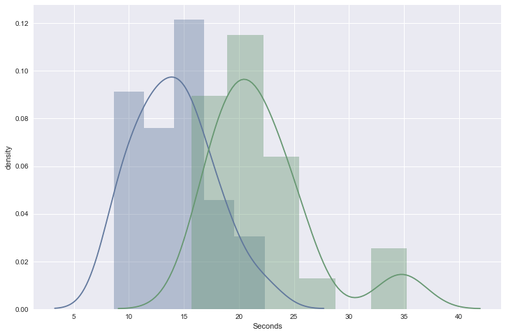

```python
plt.ylabel("density")
sns.distplot(stroop_data.Congruent.dropna(),axlabel='Seconds',label="Congruent")
sns.distplot(stroop_data.Incongruent.dropna(),axlabel='Seconds',label="Incongruent")
```

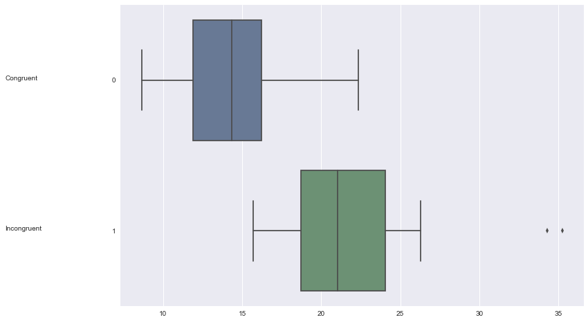

```python
plt.text(x=0, y=0, s="Congruent");
plt.text(x=0, y=1, s="Incongruent");
sns.boxplot(data=[stroop_data.Congruent,stroop_data.Incongruent],vert=False)
```

> **Note**: The **blue** color represent the data of **Congruent condition** and The **Green** color represent the data of **Incongruent condition.**

##### I am very new in jupyter so this is the best I could do.

#### Key take aways from above graphs

- In the first figure we see that both the samples are almost normally distributed.
- We see that in Incongruent condition there are some individuals who took more than 35 seconds.
- We can see the mean for Incongruent condition would be greater than the Congruent condition.
- From the second figure we can see that the median and IQR for Incongruent condition is greater than the median and IQR for Congruent condtion

#### Q5. Now, perform the statistical test and report your results. What is your confidence level and your critical statistic value? Do you reject the null hypothesis or fail to reject it? Come to a conclusion in terms of the experiment task. Did the results match up with your expectations?

**Answer:**

##### We are performed two-tailed dependent t-test for paired samples with 95% confidence Interval, Below are our results

**Degrees Of Freedom(df):** $23$  
**T-critical values at Alpha level($\alpha$) of 0.05 range:** from $-2.069$ to $+2.069$  
**$P value<0.0001$**  
**Standers Error$(SE)$ of difference:** $0.993$  
**Margin Of Error $(ME)$ :** $2.054$  
**95% Confidence Interval($CI$):** from $-10.019$ to $-5.910$  
**T-statistic $T_S$:**$8.02$

Here we see our T-statistic value is much **greater** and doesn't lie in the $95$% confidence interval, so we are **rejecting** the null hypothesis **$(H_O)$**, which means that the incongruent condition does has an effect on response time of the participants in the sample.  
Yes I think the result is **statistically significant** and does meet up our expectation that there is **significant** difference in the response time of congruent and incongruent condition.

#### Q.6. Optional: What do you think is responsible for the effects observed? Can you think of an alternative or similar task that would result in a similar effect? Some research about the problem will be helpful for thinking about these two questions!

**Answer:**

In Incongruent condition the person become confused btween the name and the actual color, which lead him/her to take more time to recognise the color.

**Alter native task**

we can put vegetables and fruits but with color they don't grew in, like guava in blue, grapes in orange, orange in magenta etc and ask the participant to name the color.

### Resouces I used

- **For Q1**: Discriptive statistic course of udacity.
- **For Q2**: https://www.youtube.com/watch?v=UaptUhOushw
- **For Q3**: Discriptive statistic course of udacity.
- **For Q4**: https://www.youtube.com/watch?v=E8OQAdQlljE,

  ```
        - http://seaborn.pydata.org/generated/seaborn.boxplot.html,
        - http://seaborn.pydata.org/generated/seaborn.distplot.html,
        - https://matplotlib.org/users/text_intro.html
  ```

- **For Q5**: Infrential Statistic course of udacity.
- **To Understand more about Stroop effect**: http://www.whatispsychology.biz/the-stroop-effect-experiment-00048,

  ```
                                         - https://www.rit.edu/cla/gssp400/sbackground.html
  ```